# clinical_analyses

#### lexical diversity

calculates the diversity of a text by modelling how the Type-Token Ratio (TTR) changes as sample sizes increase.

is age linear or quadratic?

```r
library(splines)
library(lme4)

m_lin_int <- lmer(
  VOCD_D_optimum_average ~ source_is_synthetic * clinical_group * Age_c +
    (1 | cluster_id),
  data = df_all, REML = FALSE
)

m_spline_int <- lmer(
  VOCD_D_optimum_average ~ source_is_synthetic * clinical_group +
    source_is_synthetic:ns(Age_Month, df = 3) +
    clinical_group:ns(Age_Month, df = 3) +
    ns(Age_Month, df = 3) +
    (1 | cluster_id),
  data = df_all, REML = FALSE
)

AIC(m_lin_int, m_spline_int)
```

```
##              df      AIC
## m_lin_int    10 12097.10
## m_spline_int 15 12103.09
```

```r
BIC(m_lin_int, m_spline_int)
```

```
##              df      BIC
## m_lin_int    10 12152.33
## m_spline_int 15 12185.95
```

```r
m0_vocd <- lmer(
  VOCD_D_optimum_average ~ source_is_synthetic * clinical_group  + (1 | cluster_id),
  data = df_all, REML = FALSE
)

m1_vocd <- lmer(
  VOCD_D_optimum_average ~ source_is_synthetic * clinical_group + Age_c  + (1 | cluster_id),
  data = df_all, REML = FALSE
)

m2_vocd <- lmer(
  VOCD_D_optimum_average ~ source_is_synthetic * clinical_group + Age_c +
    source_is_synthetic:Age_c + clinical_group:Age_c +
     + (1 | cluster_id),
  data = df_all, REML = FALSE
) # exploratory model: do real vs syn and td vs sli differ? does the difference depend from clinical group? does mlu change with age overall? does age slope differ by source?

m3_vocd <- lmer(
  VOCD_D_optimum_average ~ source_is_synthetic * clinical_group * Age_c +
     + (1 | cluster_id),
  data = df_all, REML = FALSE
)

anova(m0_vocd, m1_vocd, m2_vocd, m3_vocd)
```

```
## Data: df_all
## Models:
## m0_vocd: VOCD_D_optimum_average ~ source_is_synthetic * clinical_group + (1 | cluster_id)
## m1_vocd: VOCD_D_optimum_average ~ source_is_synthetic * clinical_group + Age_c + (1 | cluster_id)
## m2_vocd: VOCD_D_optimum_average ~ source_is_synthetic * clinical_group + Age_c + source_is_synthetic:Age_c + clinical_group:Age_c + +(1 | cluster_id)
## m3_vocd: VOCD_D_optimum_average ~ source_is_synthetic * clinical_group * Age_c + +(1 | cluster_id)
##         npar   AIC   BIC  logLik -2*log(L)   Chisq Df Pr(>Chisq)
## m0_vocd    6 12105 12138 -6046.3     12093
## m1_vocd    7 12092 12131 -6039.2     12078 14.2244  1  0.0001623 ***
## m2_vocd    9 12096 12146 -6039.2     12078  0.1157  2  0.9437840
## m3_vocd   10 12097 12152 -6038.5     12077  1.2393  1  0.2656073
## ---
## Signif. codes:  0 '***' 0.001 '**' 0.01 '*' 0.05 '.' 0.1 ' ' 1
```

```r
summary(m1_vocd)  # main model - do real vs syn and td vs sli differ? does the difference depend from clinical group? does mlu change with age overall?
```

```
## Linear mixed model fit by maximum likelihood . t-tests use Satterthwaite's
##   method [lmerModLmerTest]
## Formula: VOCD_D_optimum_average ~ source_is_synthetic * clinical_group +
##     Age_c + (1 | cluster_id)
##    Data: df_all
##
##       AIC       BIC    logLik -2*log(L)  df.resid
##   12092.5   12131.1   -6039.2   12078.5      1844
##
## Scaled residuals:
##     Min      1Q  Median      3Q     Max
## -4.7495 -0.2380 -0.0233  0.2235  5.1541
##
## Random effects:
##  Groups     Name        Variance Std.Dev.
##  cluster_id (Intercept) 59.96    7.744
##  Residual               27.26    5.221
## Number of obs: 1851, groups:  cluster_id, 283
##
## Fixed effects:
##                                        Estimate Std. Error        df t value
## (Intercept)                            31.26215    0.59546 285.83373  52.501
## source_is_synthetic                    14.99328    1.29921 257.88514  11.540
## clinical_groupSLI                      -5.35072    1.34526 296.43631  -3.977
## Age_c                                   0.13607    0.03558 277.43367   3.825
## source_is_synthetic:clinical_groupSLI   5.61417    1.38770 335.25023   4.046
##                                       Pr(>|t|)
## (Intercept)                            < 2e-16 ***
## source_is_synthetic                    < 2e-16 ***
## clinical_groupSLI                     8.76e-05 ***
## Age_c                                 0.000162 ***
## source_is_synthetic:clinical_groupSLI 6.48e-05 ***
## ---
## Signif. codes:  0 '***' 0.001 '**' 0.01 '*' 0.05 '.' 0.1 ' ' 1
##
## Correlation of Fixed Effects:
##             (Intr) src_s_ cl_SLI Age_c
## src_s_synth -0.458
## clncl_grSLI -0.442  0.203
## Age_c        0.038 -0.005 -0.011
## src_s_:_SLI  0.429 -0.229 -0.969  0.010
```

In the real data, SLI has lower lexical diversity than TD. In the synthetic data, lexical diversity is inflated for both groups, but especially for SLI, so the real TD–SLI difference is greatly reduced or effectively erased.

- Intercept = predicted lexical diversity for real TD in round 1 at mean age (centered)
- source_is_synthetic = TD synthetic data have a much higher lexical diversity than real transcripts.
- clinical_groupSLI = real SLI is 5.4 points lower than TD
- Age_c = lexical diversity increases with age
- source_is_synthetic:clinical_groupSLI = the synthetic-real difference is even larger in SLI than in TD.

```r
library(emmeans)

# Estimated marginal means at mean age, averaged over round
emm_vocd <- emmeans(
  m1_vocd,
  ~ source_is_synthetic * clinical_group,
  at = list(source_is_synthetic = c(0, 1))
)

emm_vocd
```

```
##  source_is_synthetic clinical_group emmean   SE  df lower.CL upper.CL
##                    0 TD               31.3 0.60 294     30.1     32.4
##                    1 TD               46.3 1.16 259     44.0     48.5
##                    0 SLI              25.9 1.21 307     23.5     28.3
##                    1 SLI              46.5 1.16 259     44.2     48.8
##
## Degrees-of-freedom method: kenward-roger
## Confidence level used: 0.95
```

```r
pairs(
  emmeans(
    m1_vocd,
    ~ source_is_synthetic | clinical_group,
    at = list(source_is_synthetic = c(0, 1))
  ),
  infer = c(TRUE, TRUE),
  adjust = "none"
)
```

```
## clinical_group = TD:
##  contrast                                    estimate   SE  df lower.CL
##  source_is_synthetic0 - source_is_synthetic1    -15.0 1.31 266    -17.6
##  upper.CL t.ratio p.value
##     -12.4 -11.454  <.0001
##
## clinical_group = SLI:
##  contrast                                    estimate   SE  df lower.CL
##  source_is_synthetic0 - source_is_synthetic1    -20.6 1.68 283    -23.9
##  upper.CL t.ratio p.value
##     -17.3 -12.249  <.0001
##
## Degrees-of-freedom method: kenward-roger
## Confidence level used: 0.95
```

- real vs synthetic TD extremely different.
- real vs synthetic SLI extremely different.

```r
pairs(
  emmeans(
    m1_vocd,
    ~ clinical_group | source_is_synthetic,
    at = list(source_is_synthetic = c(0, 1))
  ),
  infer = c(TRUE, TRUE),
  adjust = "none"
)
```

```
## source_is_synthetic = 0:
##  contrast estimate    SE   df lower.CL upper.CL t.ratio p.value
##  TD - SLI    5.351 1.350  304    2.685    8.017   3.949  0.0001
##
## source_is_synthetic = 1:
##  contrast estimate    SE   df lower.CL upper.CL t.ratio p.value
##  TD - SLI   -0.263 0.341 1569   -0.932    0.405  -0.773  0.4395
##
## Degrees-of-freedom method: kenward-roger
## Confidence level used: 0.95
```

- significant difference between real TD and SLI.
- no difference between synthetic TD and SLI.

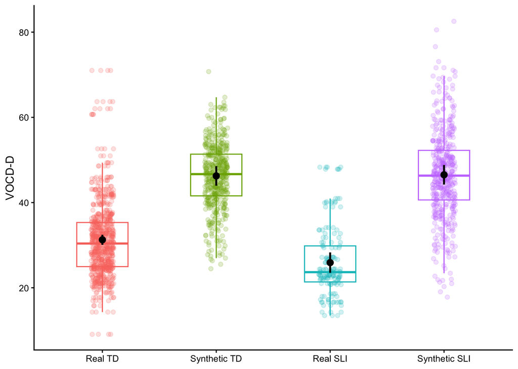

```r
library(dplyr)
library(ggplot2)
library(emmeans)

emm_vocd_df <- as.data.frame(emm_vocd) %>%
  mutate(
    population = factor(
      paste(ifelse(source_is_synthetic == 1, "Synthetic", "Real"), clinical_group),
      levels = c("Real TD", "Synthetic TD", "Real SLI", "Synthetic SLI")
    )
  )

df_plot <- df_all %>%
  mutate(
    population = factor(
      paste(ifelse(source_is_synthetic == 1, "Synthetic", "Real"), clinical_group),
      levels = c("Real TD", "Synthetic TD", "Real SLI", "Synthetic SLI")
    )
  ) %>%
  filter(!is.na(VOCD_D_optimum_average))

ggplot(df_plot, aes(x = population, y = VOCD_D_optimum_average, color = population)) +
  geom_boxplot(width = 0.45, alpha = 0.15, outlier.shape = NA) +
  geom_jitter(width = 0.10, alpha = 0.20, size = 1.7) +
  geom_pointrange(
    data = emm_vocd_df,
    aes(y = emmean, ymin = lower.CL, ymax = upper.CL),
    inherit.aes = TRUE,
    linewidth = 0.9,
    color = "black"
  ) +
  labs(
    x = NULL,
    y = "VOCD-D"
  ) +
  theme_classic() +
  theme(legend.position = "none")
```

```r
df_all %>%
  mutate(
    population = paste(ifelse(source_is_synthetic == 1, "Synthetic", "Real"), clinical_group)
  ) %>%
  group_by(population) %>%
  summarise(
    raw_mean = mean(VOCD_D_optimum_average, na.rm = TRUE),
    raw_sd = sd(VOCD_D_optimum_average, na.rm = TRUE),
    n = n(),
    .groups = "drop"
  )
```

```
## # A tibble: 4 × 4
##   population    raw_mean raw_sd     n
##   <chr>            <dbl>  <dbl> <int>
## 1 Real SLI          26.2   8.37   154
## 2 Real TD           31.2   8.86   757
## 3 Synthetic SLI     46.5  10.4    470
## 4 Synthetic TD      46.2   7.70   470
```

Real SLI much lower than TD. Synthetic no difference.

```r
summary(m2_vocd)
```

```
## Linear mixed model fit by maximum likelihood . t-tests use Satterthwaite's
##   method [lmerModLmerTest]
## Formula: VOCD_D_optimum_average ~ source_is_synthetic * clinical_group +
##     Age_c + source_is_synthetic:Age_c + clinical_group:Age_c +
##     +(1 | cluster_id)
##    Data: df_all
##
##       AIC       BIC    logLik -2*log(L)  df.resid
##   12096.3   12146.0   -6039.2   12078.3      1842
##
## Scaled residuals:
##    Min     1Q Median     3Q    Max
## -4.750 -0.239 -0.024  0.222  5.152
##
## Random effects:
##  Groups     Name        Variance Std.Dev.
##  cluster_id (Intercept) 59.98    7.744
##  Residual               27.26    5.221
## Number of obs: 1851, groups:  cluster_id, 283
##
## Fixed effects:
##                                         Estimate Std. Error         df t value
## (Intercept)                            3.127e+01  5.956e-01  2.856e+02  52.493
## source_is_synthetic                    1.498e+01  1.300e+00  2.576e+02  11.521
## clinical_groupSLI                     -5.353e+00  1.345e+00  2.962e+02  -3.979
## Age_c                                  1.420e-01  3.984e-02  2.942e+02   3.564
## source_is_synthetic:clinical_groupSLI  5.617e+00  1.388e+00  3.350e+02   4.048
## source_is_synthetic:Age_c             -3.078e-02  9.087e-02  2.534e+02  -0.339
## clinical_groupSLI:Age_c               -2.522e-04  2.368e-02  1.729e+03  -0.011
##                                       Pr(>|t|)
## (Intercept)                            < 2e-16 ***
## source_is_synthetic                    < 2e-16 ***
## clinical_groupSLI                     8.71e-05 ***
## Age_c                                 0.000426 ***
## source_is_synthetic:clinical_groupSLI 6.43e-05 ***
## source_is_synthetic:Age_c             0.735125
## clinical_groupSLI:Age_c               0.991506
## ---
## Signif. codes:  0 '***' 0.001 '**' 0.01 '*' 0.05 '.' 0.1 ' ' 1
##
## Correlation of Fixed Effects:
##             (Intr) src_s_ cl_SLI Age_c  s__:_S s__:A_
## src_s_synth -0.458
## clncl_grSLI -0.442  0.203
## Age_c        0.043 -0.019 -0.013
## src_s_:_SLI  0.429 -0.229 -0.969  0.011
## src_s_sy:A_ -0.018  0.035  0.005 -0.424 -0.007
## clnc_SLI:A_ -0.005 -0.001  0.006 -0.123  0.002 -0.063
```

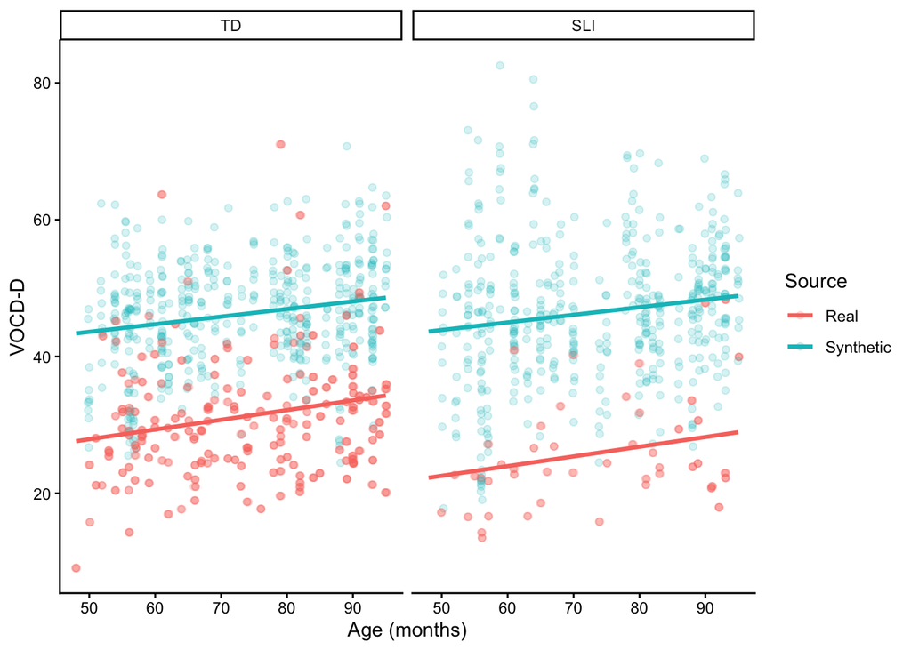

```r
library(dplyr)
library(ggplot2)
library(emmeans)

# Mean age used to convert centered age back to months for plotting
age_mean <- mean(df_all$Age_Month, na.rm = TRUE)

# Raw data for plotting
df_plot <- df_all %>%
  mutate(
    Age_Month_plot = Age_c + age_mean,
    source_label = factor(
      source_is_synthetic,
      levels = c(0, 1),
      labels = c("Real", "Synthetic")
    ),
    clinical_group = factor(clinical_group, levels = c("TD", "SLI"))
  ) %>%
  filter(
    !is.na(VOCD_D_optimum_average),
    !is.na(Age_c),
    !is.na(Age_Month_plot)
  )

# Age grid for predictions
age_grid <- seq(
  min(df_plot$Age_c, na.rm = TRUE),
  max(df_plot$Age_c, na.rm = TRUE),
  length.out = 100
)

# Model-based predictions from m2_vocd
emm_age <- emmeans(
  m2_vocd,
  ~ source_is_synthetic * clinical_group * Age_c,
  at = list(
    source_is_synthetic = c(0, 1),
    Age_c = age_grid
  )
)

pred_df <- as.data.frame(emm_age) %>%
  mutate(
    Age_Month_plot = Age_c + age_mean,
    source_label = factor(
      source_is_synthetic,
      levels = c(0, 1),
      labels = c("Real", "Synthetic")
    ),
    clinical_group = factor(clinical_group, levels = c("TD", "SLI"))
  )

# Plot
ggplot(df_plot, aes(x = Age_Month_plot, y = VOCD_D_optimum_average, color = source_label)) +
  geom_jitter(width = 0.15, height = 0, alpha = 0.18, size = 1.6) +
  geom_line(
    data = pred_df,
    aes(x = Age_Month_plot, y = emmean, color = source_label),
    linewidth = 1.1,
    inherit.aes = FALSE
  ) +
  facet_wrap(~ clinical_group) +
  labs(
    x = "Age (months)",
    y = "VOCD-D",
    color = "Source"
  ) +
  theme_classic()
```

#### developmental sentence score

is age linear or quadratic?

```r
library(splines)
library(lme4)

m_lin_int <- lmer(
  DSS_tbl_score ~ source_is_synthetic * clinical_group * Age_c +
    (1 | cluster_id),
  data = df_all, REML = FALSE
)

m_spline_int <- lmer(
  DSS_tbl_score ~ source_is_synthetic * clinical_group +
    source_is_synthetic:ns(Age_Month, df = 3) +
    clinical_group:ns(Age_Month, df = 3) +
    ns(Age_Month, df = 3) +
    (1 | cluster_id),
  data = df_all, REML = FALSE
)

AIC(m_lin_int, m_spline_int)
```

```
##              df      AIC
## m_lin_int    10 5516.651
## m_spline_int 15 5516.558
```

```r
BIC(m_lin_int, m_spline_int)
```

```
##              df      BIC
## m_lin_int    10 5571.886
## m_spline_int 15 5599.411
```

```r
m0_dss <- lmer(
  DSS_tbl_score ~ source_is_synthetic * clinical_group  + (1 | cluster_id),
  data = df_all, REML = FALSE
)

m1_dss <- lmer(
  DSS_tbl_score ~ source_is_synthetic * clinical_group + Age_c  + (1 | cluster_id),
  data = df_all, REML = FALSE
)

m2_dss <- lmer(
  DSS_tbl_score ~ source_is_synthetic * clinical_group + Age_c +
    source_is_synthetic:Age_c + clinical_group:Age_c +
     + (1 | cluster_id),
  data = df_all, REML = FALSE
)

m3_dss <- lmer(
  DSS_tbl_score ~ source_is_synthetic * clinical_group * Age_c  + (1 | cluster_id),
  data = df_all, REML = FALSE
)

anova(m0_dss, m1_dss, m2_dss, m3_dss)
```

```
## Data: df_all
## Models:
## m0_dss: DSS_tbl_score ~ source_is_synthetic * clinical_group + (1 | cluster_id)
## m1_dss: DSS_tbl_score ~ source_is_synthetic * clinical_group + Age_c + (1 | cluster_id)
## m2_dss: DSS_tbl_score ~ source_is_synthetic * clinical_group + Age_c + source_is_synthetic:Age_c + clinical_group:Age_c + +(1 | cluster_id)
## m3_dss: DSS_tbl_score ~ source_is_synthetic * clinical_group * Age_c + (1 | cluster_id)
##        npar    AIC    BIC  logLik -2*log(L)   Chisq Df Pr(>Chisq)
## m0_dss    6 5529.6 5562.8 -2758.8    5517.6
## m1_dss    7 5512.7 5551.4 -2749.4    5498.7 18.9088  1  1.371e-05 ***
## m2_dss    9 5514.7 5564.4 -2748.3    5496.7  2.0210  2      0.364
## m3_dss   10 5516.7 5571.9 -2748.3    5496.7  0.0444  1      0.833
## ---
## Signif. codes:  0 '***' 0.001 '**' 0.01 '*' 0.05 '.' 0.1 ' ' 1
```

```r
summary(m1_dss)
```

```
## Linear mixed model fit by maximum likelihood . t-tests use Satterthwaite's
##   method [lmerModLmerTest]
## Formula: DSS_tbl_score ~ source_is_synthetic * clinical_group + Age_c +
##     (1 | cluster_id)
##    Data: df_all
##
##       AIC       BIC    logLik -2*log(L)  df.resid
##    5512.7    5551.4   -2749.4    5498.7      1844
##
## Scaled residuals:
##     Min      1Q  Median      3Q     Max
## -3.6309 -0.2730 -0.0085  0.2017  6.0425
##
## Random effects:
##  Groups     Name        Variance Std.Dev.
##  cluster_id (Intercept) 2.3225   1.5240
##  Residual               0.7415   0.8611
## Number of obs: 1851, groups:  cluster_id, 283
##
## Fixed effects:
##                                         Estimate Std. Error         df t value
## (Intercept)                             9.289161   0.115374 284.547797  80.513
## source_is_synthetic                    -0.544004   0.253546 264.222633  -2.146
## clinical_groupSLI                      -1.654831   0.260004 292.183590  -6.365
## Age_c                                   0.030498   0.006906 279.210674   4.416
## source_is_synthetic:clinical_groupSLI   0.745072   0.266001 319.904169   2.801
##                                       Pr(>|t|)
## (Intercept)                            < 2e-16 ***
## source_is_synthetic                     0.0328 *
## clinical_groupSLI                     7.56e-10 ***
## Age_c                                 1.44e-05 ***
## source_is_synthetic:clinical_groupSLI   0.0054 **
## ---
## Signif. codes:  0 '***' 0.001 '**' 0.01 '*' 0.05 '.' 0.1 ' ' 1
##
## Correlation of Fixed Effects:
##             (Intr) src_s_ cl_SLI Age_c
## src_s_synth -0.455
## clncl_grSLI -0.443  0.202
## Age_c        0.040 -0.005 -0.010
## src_s_:_SLI  0.433 -0.220 -0.977  0.009
```

- Intercept = Predicted DSS for real TD at mean age.
- source_is_synthetic = In the TD group, synthetic transcripts are about 0.54 DSS points lower than real transcripts.
- clinical_groupSLI = Among real transcripts, SLI is about 1.65 DSS points lower than TD.
- Age_c = DSS increases of 0.03 points per months.
- source_is_synthetic:clinical_groupSLI = This suggests the synthetic penalty is more positive in SLI than in TD.

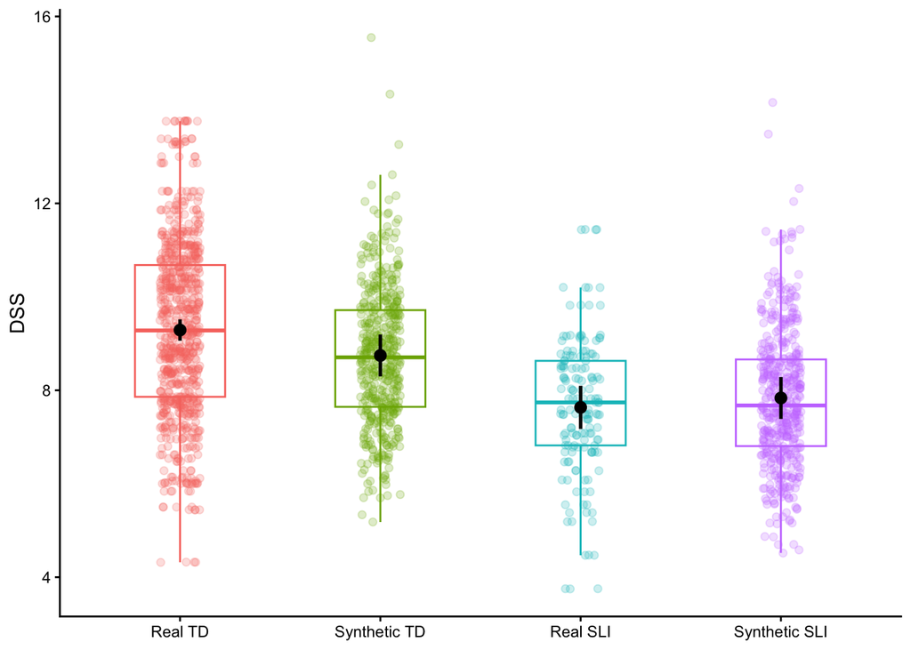

```r
# Adjusted means from the retained model
emm_dss <- emmeans(
  m1_dss,
  ~ source_is_synthetic * clinical_group,
  at = list(source_is_synthetic = c(0, 1))
)

emm_dss_df <- as.data.frame(emm_dss) %>%
  mutate(
    population = factor(
      paste(ifelse(source_is_synthetic == 1, "Synthetic", "Real"), clinical_group),
      levels = c("Real TD", "Synthetic TD", "Real SLI", "Synthetic SLI")
    )
  )

# Raw data for plotting
df_plot <- df_all %>%
  mutate(
    population = factor(
      paste(ifelse(source_is_synthetic == 1, "Synthetic", "Real"), clinical_group),
      levels = c("Real TD", "Synthetic TD", "Real SLI", "Synthetic SLI")
    )
  ) %>%
  filter(!is.na(DSS_tbl_score), !is.na(population))

# Plot
ggplot(df_plot, aes(x = population, y = DSS_tbl_score, color = population)) +
  geom_boxplot(width = 0.45, alpha = 0.15, outlier.shape = NA) +
  geom_jitter(width = 0.10, alpha = 0.22, size = 1.7) +
  geom_pointrange(
    data = emm_dss_df,
    aes(x = population, y = emmean, ymin = lower.CL, ymax = upper.CL),
    inherit.aes = FALSE,
    linewidth = 0.9,
    color = "black"
  ) +
  labs(
    x = NULL,
    y = "DSS"
  ) +
  theme_classic() +
  theme(legend.position = "none")
```

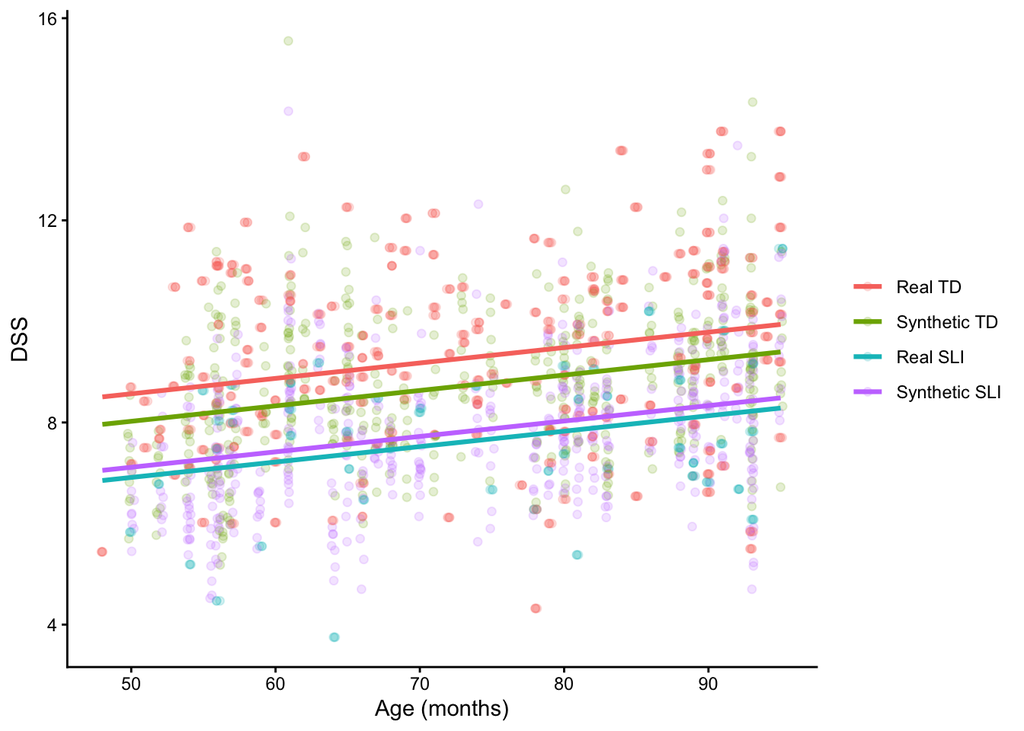

```r
library(dplyr)
library(ggplot2)
library(emmeans)

age_mean <- mean(df_all$Age_Month, na.rm = TRUE)

df_age_plot <- df_all %>%
  mutate(
    Age_Month_plot = Age_c + age_mean,
    population = factor(
      paste(ifelse(source_is_synthetic == 1, "Synthetic", "Real"), clinical_group),
      levels = c("Real TD", "Synthetic TD", "Real SLI", "Synthetic SLI")
    )
  ) %>%
  filter(!is.na(DSS_tbl_score), !is.na(Age_c), !is.na(Age_Month_plot))

age_grid <- seq(
  min(df_age_plot$Age_c, na.rm = TRUE),
  max(df_age_plot$Age_c, na.rm = TRUE),
  length.out = 100
)

emm_age <- emmeans(
  m1_dss,
  ~ source_is_synthetic * clinical_group * Age_c,
  at = list(
    source_is_synthetic = c(0, 1),
    Age_c = age_grid
  )
)

pred_df <- as.data.frame(emm_age) %>%
  mutate(
    Age_Month_plot = Age_c + age_mean,
    population = factor(
      paste(ifelse(source_is_synthetic == 1, "Synthetic", "Real"), clinical_group),
      levels = c("Real TD", "Synthetic TD", "Real SLI", "Synthetic SLI")
    )
  )

ggplot(df_age_plot, aes(x = Age_Month_plot, y = DSS_tbl_score, color = population)) +
  geom_jitter(width = 0.15, height = 0, alpha = 0.18, size = 1.6) +
  geom_line(
    data = pred_df,
    aes(x = Age_Month_plot, y = emmean, color = population),
    linewidth = 1.1
  ) +
  labs(
    x = "Age (months)",
    y = "DSS",
    color = NULL
  ) +
  theme_classic()
```

DSS is broadly clinically plausible, but the synthetic data make TD and SLI look more similar than they are in the real data.

### Productive Morphology

#### past over-generalisation

Overgeneralization is primarily a developmental phenomenon tied to productive morphology. These errors appear after acquisition of regular past tense is completed. In SLI/DLD, the better-established clinical pattern is reduced tense marking and increased zero-marking, not necessarily increased overgeneralization. They lag behind past acquisition therefore, they do not yet showcase this error pattern.

Given a past-tense opportunity, what is the probability of producing an overgeneralized past form?

```r
# -----------------------------
# Read DEV data
# -----------------------------
real_dev <- read.csv(
  "/Users/shamiraventurini/PycharmProjects/ICL-PILOT/phase2/ENNI/measures/dev_measures.csv",
  check.names = FALSE
)

syn_dev <- read.csv(
  "/Users/shamiraventurini/PycharmProjects/ICL-PILOT/phase2/generated/measures/dev_measures.csv",
  check.names = FALSE
)

# -----------------------------
# Build prompt map from synthetic metadata
# If 'syn' already exists in memory from the main feature pipeline, use it.
# Otherwise use syn_dev if it contains the prompt columns.
# -----------------------------
prompt_source <- if (exists("syn")) syn else syn_dev

prompt_source <- prompt_source %>%
  mutate(
    round_id = as.character(round_id),
    Age_Month = as.numeric(`Age(Month)`),
    age_cohort = case_when(
      Age_Month >= 48 & Age_Month < 60 ~ "4_year_old",
      Age_Month >= 60 & Age_Month < 72 ~ "5_year_old",
      Age_Month >= 72 & Age_Month < 84 ~ "6_year_old",
      Age_Month >= 84 & Age_Month < 96 ~ "7_year_old",
      TRUE ~ NA_character_
    ),
    round_batch = interaction(age_cohort, round_id, drop = TRUE)
  )

prompt_map <- prompt_source %>%
  transmute(
    round_id = as.character(round_id),
    age_cohort = as.character(age_cohort),
    round_batch = interaction(age_cohort, round_id, drop = TRUE),
    prompt_td_child_id = as.character(prompt_td_child_id),
    prompt_sli_child_id = as.character(prompt_sli_child_id)
  ) %>%
  distinct() %>%
  pivot_longer(
    cols = c(prompt_td_child_id, prompt_sli_child_id),
    names_to = "prompt_group",
    values_to = "child_id"
  ) %>%
  filter(!is.na(child_id), child_id != "") %>%
  mutate(
    clinical_group = case_when(
      prompt_group == "prompt_td_child_id"  ~ "TD",
      prompt_group == "prompt_sli_child_id" ~ "SLI"
    )
  ) %>%
  select(round_id, age_cohort, round_batch, clinical_group, child_id) %>%
  distinct()

# -----------------------------
# Real DEV pool: ages 4–7
# -----------------------------
real_dev_4to7 <- real_dev %>%
  mutate(
    File_ID = as.character(File_ID),
    Age_Month = as.numeric(`Age(Month)`),
    source = "real",
    pair_id = NA_character_,
    round_id = NA_character_,
    clinical_group = case_when(
      Group == "TD"  ~ "TD",
      Group == "SLI" ~ "SLI",
      TRUE ~ NA_character_
    ),
    age_cohort = case_when(
      Age_Month >= 48 & Age_Month < 60 ~ "4_year_old",
      Age_Month >= 60 & Age_Month < 72 ~ "5_year_old",
      Age_Month >= 72 & Age_Month < 84 ~ "6_year_old",
      Age_Month >= 84 & Age_Month < 96 ~ "7_year_old",
      TRUE ~ NA_character_
    )
  ) %>%
  filter(
    !is.na(clinical_group),
    !is.na(age_cohort),
    Age_Month >= 48, Age_Month < 96
  )

# -----------------------------
# Synthetic DEV pool: ages 4–7
# -----------------------------
syn_dev_4to7 <- syn_dev %>%
  mutate(
    File_ID = as.character(File_ID),
    pair_id = as.character(pair_id),
    round_id = as.character(round_id),
    Age_Month = as.numeric(`Age(Month)`),
    source = "synthetic",
    clinical_group = case_when(
      comparison_target_group == "TD"  ~ "TD",
      comparison_target_group == "SLI" ~ "SLI",
      TRUE ~ NA_character_
    ),
    age_cohort = case_when(
      Age_Month >= 48 & Age_Month < 60 ~ "4_year_old",
      Age_Month >= 60 & Age_Month < 72 ~ "5_year_old",
      Age_Month >= 72 & Age_Month < 84 ~ "6_year_old",
      Age_Month >= 84 & Age_Month < 96 ~ "7_year_old",
      TRUE ~ NA_character_
    ),
    round_batch = interaction(age_cohort, round_id, drop = TRUE)
  ) %>%
  filter(
    !is.na(clinical_group),
    !is.na(age_cohort),
    Age_Month >= 48, Age_Month < 96
  )

# -----------------------------
# Build fold-stacked held-out DEV dataframe
# Stack by age-specific round_batch
# -----------------------------
round_batches <- sort(unique(syn_dev_4to7$round_batch))


df_dev_all <- bind_rows(lapply(round_batches, function(rb) {

  syn_r <- syn_dev_4to7 %>%
    filter(round_batch == rb)

  cohort_r <- unique(syn_r$age_cohort)
  round_id_r <- unique(syn_r$round_id)

  if (length(cohort_r) != 1 || length(round_id_r) != 1) {
    stop(paste("Problem: round_batch", rb, "does not map uniquely to one cohort/round_id"))
  }

  prompt_r <- prompt_map %>%
    filter(round_batch == rb)

  real_r <- real_dev_4to7 %>%
    filter(age_cohort == cohort_r) %>%
    mutate(
      round_id = round_id_r,
      round_batch = rb
    ) %>%
    anti_join(
      prompt_r,
      by = c("File_ID" = "child_id", "clinical_group")
    )

  bind_rows(real_r, syn_r)
})) %>%
  mutate(
    source = factor(source, levels = c("real", "synthetic")),
    clinical_group = factor(clinical_group, levels = c("TD", "SLI")),
    source_is_synthetic = if_else(source == "synthetic", 1L, 0L),
    age_cohort = factor(
      age_cohort,
      levels = c("4_year_old", "5_year_old", "6_year_old", "7_year_old")
    ),
    cluster_id = if_else(
      source == "synthetic",
      paste0("synthetic_", age_cohort, "_", round_id, "_", pair_id),
      paste0("real_", File_ID)
    ),
    Age_c = Age_Month - mean(Age_Month, na.rm = TRUE)
  ) %>%
  filter(
    !is.na(past_overgeneralization_errors),
    !is.na(past_verb_opportunities),
    past_verb_opportunities > 0
  )

df_dev_all_clean <- df_dev_all %>%
  filter(
    past_verb_opportunities > 0,
    past_overgeneralization_errors >= 0,
    past_overgeneralization_errors <= past_verb_opportunities
  )
df_dev_all_clean <- df_dev_all_clean %>%
  mutate(Age_z = as.numeric(scale(Age_Month)))

# Quick checks
table(df_dev_all_clean$source, df_dev_all_clean$clinical_group)
```

```
##
##              TD SLI
##   real      757 154
##   synthetic 159 236
```

```r
table(df_dev_all_clean$age_cohort, df_dev_all_clean$source, df_dev_all_clean$clinical_group)
```

```
## , ,  = TD
##
##
##              real synthetic
##   4_year_old  161       109
##   5_year_old  176        20
##   6_year_old  193        14
##   7_year_old  227        16
##
## , ,  = SLI
##
##
##              real synthetic
##   4_year_old   33       109
##   5_year_old   36        47
##   6_year_old   33        44
##   7_year_old   52        36
```

```r
summary(df_dev_all_clean$past_overgeneralization_errors)
```

```
##    Min. 1st Qu.  Median    Mean 3rd Qu.    Max.
##   0.000   0.000   0.000   1.108   1.000  12.000
```

```r
summary(df_dev_all_clean$past_verb_opportunities)
```

```
##    Min. 1st Qu.  Median    Mean 3rd Qu.    Max.
##    1.00    8.00   30.00   31.82   51.00  125.00
```

is age linear or quadratic?

```r
library(lme4)

m_age0_overgen <- glmer(
  cbind(
    past_overgeneralization_errors,
    past_verb_opportunities - past_overgeneralization_errors
  ) ~
    source_is_synthetic * clinical_group +
    (1 | cluster_id),
  data = df_dev_all_clean,
  family = binomial,
  control = glmerControl(optimizer = "bobyqa", optCtrl = list(maxfun = 2e5))
)

m_age1_overgen <- glmer(
  cbind(
    past_overgeneralization_errors,
    past_verb_opportunities - past_overgeneralization_errors
  ) ~
    source_is_synthetic * clinical_group +
    Age_c +
    (1 | cluster_id),
  data = df_dev_all_clean,
  family = binomial,
  control = glmerControl(optimizer = "bobyqa", optCtrl = list(maxfun = 2e5))
)

m_age2_overgen <- glmer(
  cbind(
    past_overgeneralization_errors,
    past_verb_opportunities - past_overgeneralization_errors
  ) ~
    source_is_synthetic * clinical_group +
    Age_c + I(Age_c^2) +
    (1 | cluster_id),
  data = df_dev_all_clean,
  family = binomial,
  control = glmerControl(optimizer = "bobyqa", optCtrl = list(maxfun = 2e5))
)
anova(m_age0_overgen, m_age1_overgen, m_age2_overgen, test = "Chisq")
```

```
## Data: df_dev_all_clean
## Models:
## m_age0_overgen: cbind(past_overgeneralization_errors, past_verb_opportunities - past_overgeneralization_errors) ~ source_is_synthetic * clinical_group + (1 | cluster_id)
## m_age1_overgen: cbind(past_overgeneralization_errors, past_verb_opportunities - past_overgeneralization_errors) ~ source_is_synthetic * clinical_group + Age_c + (1 | cluster_id)
## m_age2_overgen: cbind(past_overgeneralization_errors, past_verb_opportunities - past_overgeneralization_errors) ~ source_is_synthetic * clinical_group + Age_c + I(Age_c^2) + (1 | cluster_id)
##                npar    AIC    BIC  logLik -2*log(L)   Chisq Df Pr(>Chisq)
## m_age0_overgen    5 2443.4 2469.3 -1216.7    2433.4
## m_age1_overgen    6 2427.6 2458.7 -1207.8    2415.6 17.7742  1  2.487e-05 ***
## m_age2_overgen    7 2429.6 2465.8 -1207.8    2415.6  0.0609  1     0.8051
## ---
## Signif. codes:  0 '***' 0.001 '**' 0.01 '*' 0.05 '.' 0.1 ' ' 1
```

```r
AIC(m_age0_overgen, m_age1_overgen, m_age2_overgen)
```

```
##                df      AIC
## m_age0_overgen  5 2443.385
## m_age1_overgen  6 2427.611
## m_age2_overgen  7 2429.550
```

```r
BIC(m_age0_overgen, m_age1_overgen, m_age2_overgen)
```

```
##                df      BIC
## m_age0_overgen  5 2469.258
## m_age1_overgen  6 2458.659
## m_age2_overgen  7 2465.773
```

```r
m0_overgen <- glmer(
  cbind(past_overgeneralization_errors,
        past_verb_opportunities - past_overgeneralization_errors) ~
    source_is_synthetic * clinical_group  + (1 | cluster_id),
  data = df_dev_all_clean,
  family = binomial,
  control = glmerControl(optimizer = "bobyqa", optCtrl = list(maxfun = 2e5))
) # Does the probability of past overgeneralization differ by source (real vs synthetic), by clinical group (TD vs SLI), and by the source-by-group combination, after controlling for round and repeated observations?

m1_overgen <- glmer(
  cbind(past_overgeneralization_errors,
        past_verb_opportunities - past_overgeneralization_errors) ~
    source_is_synthetic * clinical_group + Age_c  + (1 | cluster_id),
  data = df_dev_all_clean,
  family = binomial,
  control = glmerControl(optimizer = "bobyqa", optCtrl = list(maxfun = 2e5))
) # Does the probability of past overgeneralization change with age overall?

m2_overgen <- glmer(
  cbind(past_overgeneralization_errors,
        past_verb_opportunities - past_overgeneralization_errors) ~
    source_is_synthetic * clinical_group + Age_c +
    source_is_synthetic:Age_c + clinical_group:Age_c +
     + (1 | cluster_id),
  data = df_dev_all_clean,
  family = binomial,
  control = glmerControl(optimizer = "bobyqa", optCtrl = list(maxfun = 2e5))
) # Do real and synthetic data show different age slopes, or do TD and SLI show different age slopes?

m3_overgen <- glmer(
  cbind(past_overgeneralization_errors,
        past_verb_opportunities - past_overgeneralization_errors) ~
    source_is_synthetic * clinical_group * Age_c +
     + (1 | cluster_id),
  data = df_dev_all_clean,
  family = binomial,
  control = glmerControl(optimizer = "bobyqa", optCtrl = list(maxfun = 2e5))
) # Is the developmental pattern of past overgeneralization across age and clinical group reproduced differently in synthetic versus real data?

anova(m0_overgen, m1_overgen, m2_overgen, m3_overgen, test = "Chisq")
```

```
## Data: df_dev_all_clean
## Models:
## m0_overgen: cbind(past_overgeneralization_errors, past_verb_opportunities - past_overgeneralization_errors) ~ source_is_synthetic * clinical_group + (1 | cluster_id)
## m1_overgen: cbind(past_overgeneralization_errors, past_verb_opportunities - past_overgeneralization_errors) ~ source_is_synthetic * clinical_group + Age_c + (1 | cluster_id)
## m2_overgen: cbind(past_overgeneralization_errors, past_verb_opportunities - past_overgeneralization_errors) ~ source_is_synthetic * clinical_group + Age_c + source_is_synthetic:Age_c + clinical_group:Age_c + +(1 | cluster_id)
## m3_overgen: cbind(past_overgeneralization_errors, past_verb_opportunities - past_overgeneralization_errors) ~ source_is_synthetic * clinical_group * Age_c + +(1 | cluster_id)
##            npar    AIC    BIC  logLik -2*log(L)  Chisq Df Pr(>Chisq)
## m0_overgen    5 2443.4 2469.3 -1216.7    2433.4
## m1_overgen    6 2427.6 2458.7 -1207.8    2415.6 17.774  1  2.487e-05 ***
## m2_overgen    8 2401.7 2443.1 -1192.9    2385.7 29.898  2  3.219e-07 ***
## m3_overgen    9 2395.0 2441.6 -1188.5    2377.0  8.692  1   0.003196 **
## ---
## Signif. codes:  0 '***' 0.001 '**' 0.01 '*' 0.05 '.' 0.1 ' ' 1
```

```r
summary(m3_overgen) # Does the developmental pattern across age differ jointly by source and clinical group?
```

```
## Generalized linear mixed model fit by maximum likelihood (Laplace
##   Approximation) [glmerMod]
##  Family: binomial  ( logit )
## Formula: cbind(past_overgeneralization_errors, past_verb_opportunities -
##     past_overgeneralization_errors) ~ source_is_synthetic * clinical_group *
##     Age_c + +(1 | cluster_id)
##    Data: df_dev_all_clean
## Control: glmerControl(optimizer = "bobyqa", optCtrl = list(maxfun = 2e+05))
##
##       AIC       BIC    logLik -2*log(L)  df.resid
##    2395.0    2441.6   -1188.5    2377.0      1297
##
## Scaled residuals:
##     Min      1Q  Median      3Q     Max
## -0.8422 -0.3077 -0.1474  0.0639  8.6352
##
## Random effects:
##  Groups     Name        Variance Std.Dev.
##  cluster_id (Intercept) 2.346    1.532
## Number of obs: 1306, groups:  cluster_id, 281
##
## Fixed effects:
##                                             Estimate Std. Error z value
## (Intercept)                                 -4.30559    0.14816 -29.060
## source_is_synthetic                          0.08881    0.51415   0.173
## clinical_groupSLI                            0.94593    0.28951   3.267
## Age_c                                       -0.07026    0.01023  -6.869
## source_is_synthetic:clinical_groupSLI       -0.11772    0.54841  -0.215
## source_is_synthetic:Age_c                    0.16962    0.03219   5.269
## clinical_groupSLI:Age_c                      0.07665    0.02121   3.614
## source_is_synthetic:clinical_groupSLI:Age_c -0.10750    0.03429  -3.135
##                                             Pr(>|z|)
## (Intercept)                                  < 2e-16 ***
## source_is_synthetic                         0.862859
## clinical_groupSLI                           0.001086 **
## Age_c                                       6.46e-12 ***
## source_is_synthetic:clinical_groupSLI       0.830040
## source_is_synthetic:Age_c                   1.37e-07 ***
## clinical_groupSLI:Age_c                     0.000301 ***
## source_is_synthetic:clinical_groupSLI:Age_c 0.001717 **
## ---
## Signif. codes:  0 '***' 0.001 '**' 0.01 '*' 0.05 '.' 0.1 ' ' 1
##
## Correlation of Fixed Effects:
##             (Intr) src_s_ cl_SLI Age_c  sr__:_SLI s__:A_ c_SLI:
## src_s_synth -0.245
## clncl_grSLI -0.436  0.122
## Age_c        0.275 -0.060 -0.107
## src_s_:_SLI  0.226 -0.684 -0.528  0.054
## src_s_sy:A_ -0.071  0.458  0.033 -0.311 -0.412
## clnc_SLI:A_ -0.147  0.030  0.012 -0.489 -0.005     0.150
## s__:_SLI:A_  0.082 -0.420 -0.007  0.298  0.460    -0.600 -0.616
```

At mean age, real and synthetic data are fairly similar in overall past-overgeneralization rate, but they differ sharply in how that rate changes with age.

- real TD lower overgeneralisation probability than SLI
- synthetic vs real TD and synthetic vs real SLI not significantly different at mean age
- real TD probability of continue overgeneralising decreases with age
- real SLI have an almost flat slope or only slightly positive INTERESTING PART:
- synthetic TD and SLI probability of overgeneralisation INCREASES WITH AGE -> flipped developmental pattern
- synthetic SLI slope is also different from synthetic TD

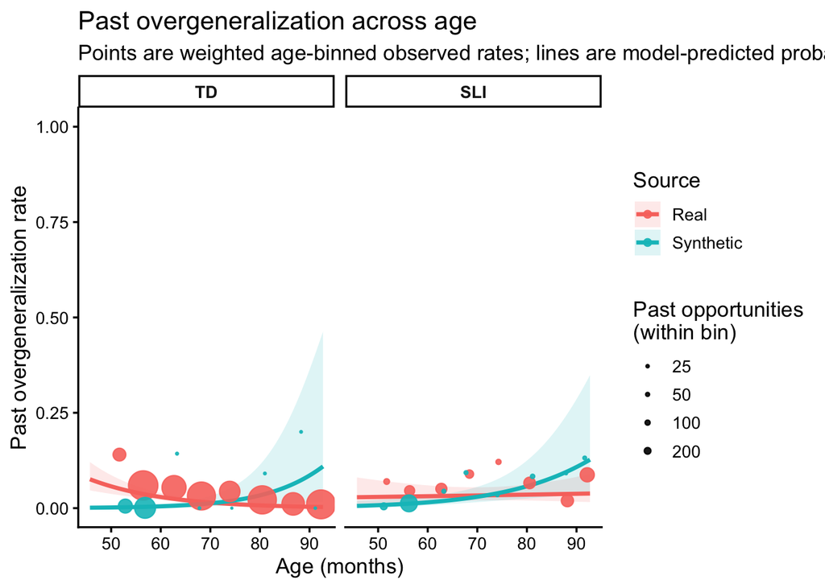

```r
library(dplyr)
library(ggplot2)

# -----------------------------
# Cleaner plot for m3_overgen
# - points = age-binned observed means
# - lines/ribbons = model-predicted probabilities
# -----------------------------

# 1) Add observed rate
plot_df <- df_dev_all_clean %>%
  mutate(
    obs_rate = past_overgeneralization_errors / past_verb_opportunities,
    source_label = factor(
      source_is_synthetic,
      levels = c(0, 1),
      labels = c("Real", "Synthetic")
    ),
    clinical_group = factor(clinical_group, levels = c("TD", "SLI"))
  )

# 2) Create 6-month age bins
plot_df <- plot_df %>%
  mutate(
    age_bin = cut(
      Age_Month,
      breaks = c(48, 54, 60, 66, 72, 78, 84, 90, 96),
      right = FALSE,
      include.lowest = TRUE
    )
  )

# 3) Compute binned observed means
#    Weighted by past opportunities, so rows with more opportunities count more
binned_df <- plot_df %>%
  group_by(clinical_group, source_label, age_bin) %>%
  summarise(
    Age_Month_plot = weighted.mean(Age_Month, w = past_verb_opportunities, na.rm = TRUE),
    obs_rate = sum(past_overgeneralization_errors, na.rm = TRUE) /
      sum(past_verb_opportunities, na.rm = TRUE),
    total_opp = sum(past_verb_opportunities, na.rm = TRUE),
    n = n(),
    .groups = "drop"
  )

# 4) Prediction grid from m3_overgen
age_grid <- seq(
  min(df_dev_all_clean$Age_c, na.rm = TRUE),
  max(df_dev_all_clean$Age_c, na.rm = TRUE),
  length.out = 150
)

newdat <- expand.grid(
  Age_c = age_grid,
  source_is_synthetic = c(0, 1),
  clinical_group = c("TD", "SLI")
) %>%
  mutate(
    clinical_group = factor(clinical_group, levels = levels(df_dev_all_clean$clinical_group)),
    source_is_synthetic = as.integer(source_is_synthetic)
  )

X <- model.matrix(
  ~ source_is_synthetic * clinical_group * Age_c,
  data = newdat
)

beta <- lme4::fixef(m3_overgen)
V <- as.matrix(vcov(m3_overgen))

eta <- as.numeric(X %*% beta)
se_eta <- sqrt(diag(X %*% V %*% t(X)))

newdat <- newdat %>%
  mutate(
    Age_Month_plot = Age_c + mean(df_dev_all_clean$Age_Month, na.rm = TRUE),
    fit_link = eta,
    lower_link = eta - 1.96 * se_eta,
    upper_link = eta + 1.96 * se_eta,
    fit = plogis(fit_link),
    lower = plogis(lower_link),
    upper = plogis(upper_link),
    source_label = factor(
      source_is_synthetic,
      levels = c(0, 1),
      labels = c("Real", "Synthetic")
    ),
    clinical_group = factor(clinical_group, levels = c("TD", "SLI"))
  )

# 5) Plot
ggplot() +
  geom_ribbon(
    data = newdat,
    aes(
      x = Age_Month_plot,
      ymin = lower,
      ymax = upper,
      fill = source_label
    ),
    alpha = 0.14,
    color = NA
  ) +
  geom_line(
    data = newdat,
    aes(
      x = Age_Month_plot,
      y = fit,
      color = source_label
    ),
    linewidth = 1.2
  ) +
  geom_point(
    data = binned_df,
    aes(
      x = Age_Month_plot,
      y = obs_rate,
      color = source_label,
      size = total_opp
    ),
    alpha = 0.9
  ) +
  facet_wrap(~ clinical_group, nrow = 1) +
  scale_size_area(
    max_size = 8,
    breaks = c(25, 50, 100, 200),
    labels = c("25", "50", "100", "200")
  ) +
  labs(
    x = "Age (months)",
    y = "Past overgeneralization rate",
    color = "Source",
    fill = "Source",
    size = "Past opportunities\n(within bin)",
    title = "Past overgeneralization across age",
    subtitle = "Points are weighted age-binned observed rates; lines are model-predicted probabilities"
  ) +
  coord_cartesian(ylim = c(0, 1)) +
  theme_classic(base_size = 13) +
  theme(
    legend.position = "right",
    strip.background = element_rect(fill = "white", color = "black"),
    strip.text = element_text(face = "bold")
  )
```

#### non-finiteness

is age linear or quadratic?

```r
library(splines)
library(lme4)

m_lin_int <- lmer(
  bare_marking_errors_per_word ~ source_is_synthetic * clinical_group * Age_c +
    (1 | cluster_id),
  data = df_all, REML = FALSE
)

m_spline_int <- lmer(
  bare_marking_errors_per_word ~ source_is_synthetic * clinical_group +
    source_is_synthetic:ns(Age_Month, df = 3) +
    clinical_group:ns(Age_Month, df = 3) +
    ns(Age_Month, df = 3) +
    (1 | cluster_id),
  data = df_all, REML = FALSE
)

AIC(m_lin_int, m_spline_int)
```

```
##              df       AIC
## m_lin_int    10 -10848.65
## m_spline_int 15 -10814.23
```

```r
BIC(m_lin_int, m_spline_int)
```

```
##              df       BIC
## m_lin_int    10 -10793.42
## m_spline_int 15 -10731.38
```

```r
library(lme4)
library(lmerTest)

m0_bare <- lmer(
  bare_marking_errors_per_word ~ source_is_synthetic * clinical_group +
     + (1 | cluster_id),
  data = df_all,
  REML = FALSE
) # Does nonfiniteness differ by source, by clinical group, and by their interaction?

m1_bare <- lmer(
  bare_marking_errors_per_word ~ source_is_synthetic * clinical_group +
    Age_c  + (1 | cluster_id),
  data = df_all,
  REML = FALSE
)

m2_bare <- lmer(
  bare_marking_errors_per_word ~ source_is_synthetic * clinical_group +
    Age_c +
    source_is_synthetic:Age_c +
    clinical_group:Age_c +
     + (1 | cluster_id),
  data = df_all,
  REML = FALSE
)

m3_bare <- lmer(
  bare_marking_errors_per_word ~ source_is_synthetic * clinical_group * Age_c +
     + (1 | cluster_id),
  data = df_all,
  REML = FALSE
)

anova(m0_bare, m1_bare, m2_bare, m3_bare)
```

```
## Data: df_all
## Models:
## m0_bare: bare_marking_errors_per_word ~ source_is_synthetic * clinical_group + +(1 | cluster_id)
## m1_bare: bare_marking_errors_per_word ~ source_is_synthetic * clinical_group + Age_c + (1 | cluster_id)
## m2_bare: bare_marking_errors_per_word ~ source_is_synthetic * clinical_group + Age_c + source_is_synthetic:Age_c + clinical_group:Age_c + +(1 | cluster_id)
## m3_bare: bare_marking_errors_per_word ~ source_is_synthetic * clinical_group * Age_c + +(1 | cluster_id)
##         npar    AIC    BIC logLik -2*log(L)   Chisq Df Pr(>Chisq)
## m0_bare    6 -10760 -10726 5385.8    -10772
## m1_bare    7 -10762 -10723 5387.9    -10776  4.1958  1    0.04052 *
## m2_bare    9 -10813 -10763 5415.4    -10831 55.0062  2  1.136e-12 ***
## m3_bare   10 -10849 -10793 5434.3    -10869 37.8653  1  7.580e-10 ***
## ---
## Signif. codes:  0 '***' 0.001 '**' 0.01 '*' 0.05 '.' 0.1 ' ' 1
```

```r
summary(m3_bare)
```

```
## Linear mixed model fit by maximum likelihood . t-tests use Satterthwaite's
##   method [lmerModLmerTest]
## Formula: bare_marking_errors_per_word ~ source_is_synthetic * clinical_group *
##     Age_c + +(1 | cluster_id)
##    Data: df_all
##
##       AIC       BIC    logLik -2*log(L)  df.resid
##  -10848.6  -10793.4    5434.3  -10868.6      1841
##
## Scaled residuals:
##     Min      1Q  Median      3Q     Max
## -3.0652 -0.2800 -0.0251  0.2054  6.8936
##
## Random effects:
##  Groups     Name        Variance  Std.Dev.
##  cluster_id (Intercept) 4.978e-05 0.007055
##  Residual               1.402e-04 0.011842
## Number of obs: 1851, groups:  cluster_id, 283
##
## Fixed effects:
##                                               Estimate Std. Error         df
## (Intercept)                                  1.269e-03  6.719e-04  4.288e+02
## source_is_synthetic                          4.336e-03  1.345e-03  2.821e+02
## clinical_groupSLI                            1.087e-02  1.559e-03  4.894e+02
## Age_c                                       -3.842e-05  4.985e-05  4.189e+02
## source_is_synthetic:clinical_groupSLI        1.346e-02  1.740e-03  7.090e+02
## source_is_synthetic:Age_c                   -2.644e-04  9.706e-05  2.833e+02
## clinical_groupSLI:Age_c                      3.858e-04  1.121e-04  4.727e+02
## source_is_synthetic:clinical_groupSLI:Age_c -7.804e-04  1.251e-04  6.858e+02
##                                             t value Pr(>|t|)
## (Intercept)                                   1.889 0.059508 .
## source_is_synthetic                           3.223 0.001419 **
## clinical_groupSLI                             6.970 1.03e-11 ***
## Age_c                                        -0.771 0.441317
## source_is_synthetic:clinical_groupSLI         7.736 3.53e-14 ***
## source_is_synthetic:Age_c                    -2.724 0.006841 **
## clinical_groupSLI:Age_c                       3.440 0.000633 ***
## source_is_synthetic:clinical_groupSLI:Age_c  -6.240 7.64e-10 ***
## ---
## Signif. codes:  0 '***' 0.001 '**' 0.01 '*' 0.05 '.' 0.1 ' ' 1
##
## Correlation of Fixed Effects:
##             (Intr) src_s_ cl_SLI Age_c  sr__:_SLI s__:A_ c_SLI:
## src_s_synth -0.499
## clncl_grSLI -0.431  0.215
## Age_c        0.023 -0.012 -0.010
## src_s_:_SLI  0.386 -0.320 -0.896  0.009
## src_s_sy:A_ -0.012  0.031  0.005 -0.514 -0.010
## clnc_SLI:A_ -0.010  0.005 -0.010 -0.445  0.009     0.228
## s__:_SLI:A_  0.009 -0.009  0.009  0.399 -0.001    -0.328 -0.897
```

the developmental pattern of bare marking errors is different across the four groups, not just in level but in trajectory. * at mean age td has a very low bare-marking error rate * synthetic td is higher than real td * real sli is higher than td * synthetic sli much higher

SYNTHETIC DATA INFLATE BARE MARKING ERRORS ESPECIALLY FOR SLI

- no effect of age for td = number of error stays low and costant
- sli errors increase with age (not a worsening of condition but more opportunities probably)
- synthetic sli errors decrease considerably with age

SYNTHETIC DATA PRODUCE THE WRONG DEVELOPMENTAL TRAJECTORY

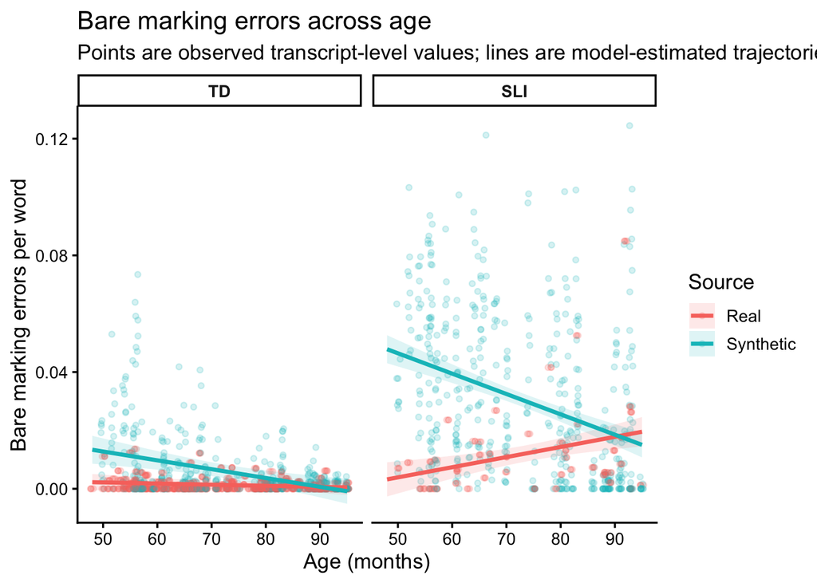

```r
library(dplyr)
library(ggplot2)
library(emmeans)

# -----------------------------
# Predicted trajectories from m3_bare
# -----------------------------
age_grid <- seq(
  min(df_all$Age_c, na.rm = TRUE),
  max(df_all$Age_c, na.rm = TRUE),
  length.out = 150
)

emm_bare <- emmeans(
  m3_bare,
  ~ source_is_synthetic * clinical_group * Age_c,
  at = list(Age_c = age_grid)
)

emm_bare_df <- as.data.frame(emm_bare) %>%
  mutate(
    Age_Month_plot = Age_c + mean(df_all$Age_Month, na.rm = TRUE),
    source_label = factor(
      source_is_synthetic,
      levels = c(0, 1),
      labels = c("Real", "Synthetic")
    ),
    clinical_group = factor(clinical_group, levels = c("TD", "SLI"))
  )

# -----------------------------
# Observed data
# -----------------------------
plot_df <- df_all %>%
  mutate(
    source_label = factor(
      source_is_synthetic,
      levels = c(0, 1),
      labels = c("Real", "Synthetic")
    ),
    clinical_group = factor(clinical_group, levels = c("TD", "SLI"))
  )

# -----------------------------
# Plot
# -----------------------------
ggplot(plot_df, aes(x = Age_Month, y = bare_marking_errors_per_word, color = source_label)) +
  geom_jitter(width = 0.35, height = 0, alpha = 0.18, size = 1.3) +
  geom_ribbon(
    data = emm_bare_df,
    aes(
      x = Age_Month_plot,
      y = emmean,
      ymin = lower.CL,
      ymax = upper.CL,
      fill = source_label
    ),
    alpha = 0.14,
    colour = NA,
    inherit.aes = FALSE
  ) +
  geom_line(
    data = emm_bare_df,
    aes(
      x = Age_Month_plot,
      y = emmean,
      color = source_label
    ),
    linewidth = 1.2,
    inherit.aes = FALSE
  ) +
  facet_wrap(~ clinical_group, nrow = 1) +
  labs(
    x = "Age (months)",
    y = "Bare marking errors per word",
    color = "Source",
    fill = "Source",
    title = "Bare marking errors across age",
    subtitle = "Points are observed transcript-level values; lines are model-estimated trajectories"
  ) +
  theme_classic(base_size = 13) +
  theme(
    legend.position = "right",
    strip.background = element_rect(fill = "white", color = "black"),
    strip.text = element_text(face = "bold")
  )
```

#### agreement is age linear or quadratic?

```r
library(splines)
library(lme4)

m_lin_int <- lmer(
  agreement_errors_per_finite_verb ~ source_is_synthetic * clinical_group * Age_c +
    (1 | cluster_id),
  data = df_all, REML = FALSE
)

m_spline_int <- lmer(
  agreement_errors_per_finite_verb ~ source_is_synthetic * clinical_group +
    source_is_synthetic:ns(Age_Month, df = 3) +
    clinical_group:ns(Age_Month, df = 3) +
    ns(Age_Month, df = 3) +
    (1 | cluster_id),
  data = df_all, REML = FALSE
)
```

```
## fixed-effect model matrix is rank deficient so dropping 1 column / coefficient
```

```r
AIC(m_lin_int, m_spline_int)
```

```
##              df       AIC
## m_lin_int    10 -2944.279
## m_spline_int 14 -2951.296
```

```r
BIC(m_lin_int, m_spline_int)
```

```
##              df       BIC
## m_lin_int    10 -2893.971
## m_spline_int 14 -2880.864
```

```r
m0_agr <- lmer(
  agreement_errors_per_finite_verb ~ source_is_synthetic * clinical_group +
     + (1 | cluster_id),
  data = df_all,
  REML = FALSE
)

m1_agr <- lmer(
  agreement_errors_per_finite_verb ~ source_is_synthetic * clinical_group +
    Age_c  + (1 | cluster_id),
  data = df_all,
  REML = FALSE
)

m2_agr <- lmer(
  agreement_errors_per_finite_verb ~ source_is_synthetic * clinical_group +
    Age_c +
    source_is_synthetic:Age_c +
    clinical_group:Age_c +
     + (1 | cluster_id),
  data = df_all,
  REML = FALSE
)

m3_agr <- lmer(
  agreement_errors_per_finite_verb ~ source_is_synthetic * clinical_group * Age_c +
     + (1 | cluster_id),
  data = df_all,
  REML = FALSE
)

anova(m0_agr, m1_agr, m2_agr, m3_agr)
```

```
## Data: df_all
## Models:
## m0_agr: agreement_errors_per_finite_verb ~ source_is_synthetic * clinical_group + +(1 | cluster_id)
## m1_agr: agreement_errors_per_finite_verb ~ source_is_synthetic * clinical_group + Age_c + (1 | cluster_id)
## m2_agr: agreement_errors_per_finite_verb ~ source_is_synthetic * clinical_group + Age_c + source_is_synthetic:Age_c + clinical_group:Age_c + +(1 | cluster_id)
## m3_agr: agreement_errors_per_finite_verb ~ source_is_synthetic * clinical_group * Age_c + +(1 | cluster_id)
##        npar     AIC     BIC logLik -2*log(L)   Chisq Df Pr(>Chisq)
## m0_agr    6 -2937.0 -2906.8 1474.5   -2949.0
## m1_agr    7 -2935.0 -2899.8 1474.5   -2949.0  0.0223  1   0.881324
## m2_agr    9 -2944.6 -2899.3 1481.3   -2962.6 13.5790  2   0.001126 **
## m3_agr   10 -2944.3 -2894.0 1482.1   -2964.3  1.7024  1   0.191977
## ---
## Signif. codes:  0 '***' 0.001 '**' 0.01 '*' 0.05 '.' 0.1 ' ' 1
```

```r
summary(m2_agr)
```

```
## Linear mixed model fit by maximum likelihood . t-tests use Satterthwaite's
##   method [lmerModLmerTest]
## Formula:
## agreement_errors_per_finite_verb ~ source_is_synthetic * clinical_group +
##     Age_c + source_is_synthetic:Age_c + clinical_group:Age_c +
##     +(1 | cluster_id)
##    Data: df_all
##
##       AIC       BIC    logLik -2*log(L)  df.resid
##   -2944.6   -2899.3    1481.3   -2962.6      1122
##
## Scaled residuals:
##     Min      1Q  Median      3Q     Max
## -4.1560 -0.0677 -0.0265  0.0285 11.0684
##
## Random effects:
##  Groups     Name        Variance Std.Dev.
##  cluster_id (Intercept) 0.003288 0.05734
##  Residual               0.002921 0.05405
## Number of obs: 1131, groups:  cluster_id, 247
##
## Fixed effects:
##                                         Estimate Std. Error         df t value
## (Intercept)                            1.265e-02  4.622e-03  2.471e+02   2.737
## source_is_synthetic                   -1.776e-01  1.346e-01  1.934e+02  -1.320
## clinical_groupSLI                      8.738e-02  1.051e-02  2.633e+02   8.311
## Age_c                                 -5.103e-04  3.421e-04  2.500e+02  -1.492
## source_is_synthetic:clinical_groupSLI  1.411e-01  1.860e-02  3.986e+02   7.587
## source_is_synthetic:Age_c             -1.342e-02  7.198e-03  1.929e+02  -1.864
## clinical_groupSLI:Age_c                2.379e-03  7.376e-04  2.909e+02   3.225
##                                       Pr(>|t|)
## (Intercept)                            0.00666 **
## source_is_synthetic                    0.18849
## clinical_groupSLI                     5.09e-15 ***
## Age_c                                  0.13702
## source_is_synthetic:clinical_groupSLI 2.33e-13 ***
## source_is_synthetic:Age_c              0.06387 .
## clinical_groupSLI:Age_c                0.00140 **
## ---
## Signif. codes:  0 '***' 0.001 '**' 0.01 '*' 0.05 '.' 0.1 ' ' 1
##
## Correlation of Fixed Effects:
##             (Intr) src_s_ cl_SLI Age_c  s__:_S s__:A_
## src_s_synth -0.034
## clncl_grSLI -0.440  0.015
## Age_c        0.041  0.007 -0.018
## src_s_:_SLI  0.235 -0.048 -0.555 -0.314
## src_s_sy:A_ -0.002  0.989  0.001 -0.039 -0.014
## clnc_SLI:A_ -0.018 -0.018  0.014 -0.442  0.726  0.002
```

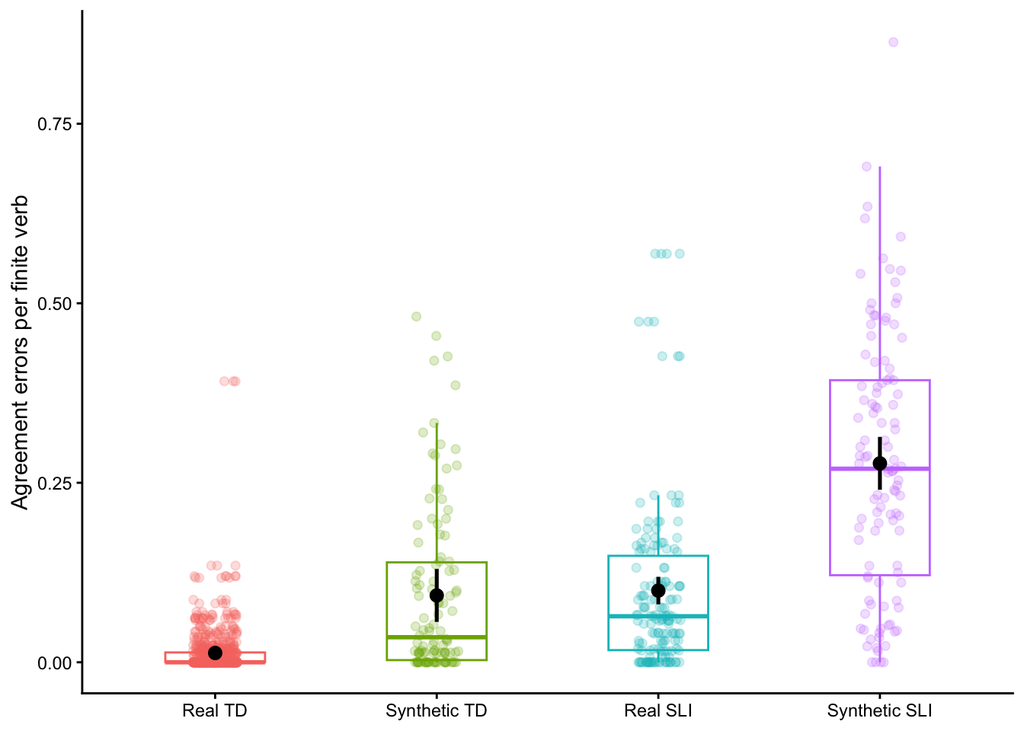

```r
library(dplyr)
library(ggplot2)
library(emmeans)

# Adjusted means from the retained model
emm_agr <- emmeans(
  m0_agr,
  ~ source_is_synthetic * clinical_group,
  at = list(source_is_synthetic = c(0, 1))
)

emm_agr_df <- as.data.frame(emm_agr) %>%
  mutate(
    population = factor(
      paste(ifelse(source_is_synthetic == 1, "Synthetic", "Real"), clinical_group),
      levels = c("Real TD", "Synthetic TD", "Real SLI", "Synthetic SLI")
    )
  )

# Raw data
df_plot <- df_all %>%
  mutate(
    population = factor(
      paste(ifelse(source_is_synthetic == 1, "Synthetic", "Real"), clinical_group),
      levels = c("Real TD", "Synthetic TD", "Real SLI", "Synthetic SLI")
    )
  ) %>%
  filter(!is.na(agreement_errors_per_finite_verb), !is.na(population))

# Plot
ggplot(df_plot, aes(x = population, y = agreement_errors_per_finite_verb, color = population)) +
  geom_boxplot(width = 0.45, alpha = 0.15, outlier.shape = NA) +
  geom_jitter(width = 0.10, alpha = 0.22, size = 1.7) +
  geom_pointrange(
    data = emm_agr_df,
    aes(x = population, y = emmean, ymin = lower.CL, ymax = upper.CL),
    inherit.aes = FALSE,
    linewidth = 0.9,
    color = "black"
  ) +
  labs(
    x = NULL,
    y = "Agreement errors per finite verb"
  ) +
  theme_classic() +
  theme(legend.position = "none")
```

The synthetic data inflate morphosyntactic error rates, and the inflation is especially strong for SLI.

### Usage Measures

#### auxiliaries

is age linear or quadratic?

```r
library(splines)
library(lme4)

m_lin_int <- lmer(
  Syntax_AuxCop_Utt_Prop ~ source_is_synthetic * clinical_group * Age_c +
    (1 | cluster_id),
  data = df_all, REML = FALSE
)

m_spline_int <- lmer(
  Syntax_AuxCop_Utt_Prop ~ source_is_synthetic * clinical_group +
    source_is_synthetic:ns(Age_Month, df = 3) +
    clinical_group:ns(Age_Month, df = 3) +
    ns(Age_Month, df = 3) +
    (1 | cluster_id),
  data = df_all, REML = FALSE
)

AIC(m_lin_int, m_spline_int)
```

```
##              df       AIC
## m_lin_int    10 -6009.279
## m_spline_int 15 -6019.458
```

```r
BIC(m_lin_int, m_spline_int)
```

```
##              df       BIC
## m_lin_int    10 -5954.044
## m_spline_int 15 -5936.606
```

```r
m0_auxcop <- lmer(
  Syntax_AuxCop_Utt_Prop ~ source_is_synthetic * clinical_group +
     + (1 | cluster_id),
  data = df_all,
  REML = FALSE
)

m1_auxcop <- lmer(
  Syntax_AuxCop_Utt_Prop ~ source_is_synthetic * clinical_group +
    Age_c  + (1 | cluster_id),
  data = df_all,
  REML = FALSE
)

m2_auxcop <- lmer(
  Syntax_AuxCop_Utt_Prop ~ source_is_synthetic * clinical_group +
    Age_c +
    source_is_synthetic:Age_c +
    clinical_group:Age_c +
     + (1 | cluster_id),
  data = df_all,
  REML = FALSE
)

m3_auxcop <- lmer(
  Syntax_AuxCop_Utt_Prop ~ source_is_synthetic * clinical_group * Age_c +
     + (1 | cluster_id),
  data = df_all,
  REML = FALSE
)

anova(m0_auxcop, m1_auxcop, m2_auxcop, m3_auxcop)
```

```
## Data: df_all
## Models:
## m0_auxcop: Syntax_AuxCop_Utt_Prop ~ source_is_synthetic * clinical_group + +(1 | cluster_id)
## m1_auxcop: Syntax_AuxCop_Utt_Prop ~ source_is_synthetic * clinical_group + Age_c + (1 | cluster_id)
## m2_auxcop: Syntax_AuxCop_Utt_Prop ~ source_is_synthetic * clinical_group + Age_c + source_is_synthetic:Age_c + clinical_group:Age_c + +(1 | cluster_id)
## m3_auxcop: Syntax_AuxCop_Utt_Prop ~ source_is_synthetic * clinical_group * Age_c + +(1 | cluster_id)
##           npar     AIC     BIC logLik -2*log(L)   Chisq Df Pr(>Chisq)
## m0_auxcop    6 -5995.5 -5962.4 3003.8   -6007.5
## m1_auxcop    7 -5993.7 -5955.0 3003.8   -6007.7  0.1168  1     0.7325
## m2_auxcop    9 -6011.1 -5961.4 3014.6   -6029.1 21.4445  2  2.205e-05 ***
## m3_auxcop   10 -6009.3 -5954.0 3014.6   -6029.3  0.1699  1     0.6802
## ---
## Signif. codes:  0 '***' 0.001 '**' 0.01 '*' 0.05 '.' 0.1 ' ' 1
```

```r
summary(m2_auxcop)
```

```
## Linear mixed model fit by maximum likelihood . t-tests use Satterthwaite's
##   method [lmerModLmerTest]
## Formula: Syntax_AuxCop_Utt_Prop ~ source_is_synthetic * clinical_group +
##     Age_c + source_is_synthetic:Age_c + clinical_group:Age_c +
##     +(1 | cluster_id)
##    Data: df_all
##
##       AIC       BIC    logLik -2*log(L)  df.resid
##   -6011.1   -5961.4    3014.6   -6029.1      1842
##
## Scaled residuals:
##     Min      1Q  Median      3Q     Max
## -8.4006 -0.0604 -0.0053  0.0595 10.7413
##
## Random effects:
##  Groups     Name        Variance Std.Dev.
##  cluster_id (Intercept) 0.014437 0.12015
##  Residual               0.001201 0.03465
## Number of obs: 1851, groups:  cluster_id, 283
##
## Fixed effects:
##                                         Estimate Std. Error         df t value
## (Intercept)                            2.702e-01  8.843e-03  2.827e+02  30.562
## source_is_synthetic                   -2.169e-01  1.970e-02  2.770e+02 -11.006
## clinical_groupSLI                     -2.258e-02  1.983e-02  2.848e+02  -1.139
## Age_c                                  6.844e-04  5.876e-04  2.847e+02   1.165
## source_is_synthetic:clinical_groupSLI  1.869e-02  1.996e-02  2.922e+02   0.936
## source_is_synthetic:Age_c             -5.266e-03  1.369e-03  2.913e+02  -3.846
## clinical_groupSLI:Age_c                4.324e-04  1.611e-04  1.609e+03   2.683
##                                       Pr(>|t|)
## (Intercept)                            < 2e-16 ***
## source_is_synthetic                    < 2e-16 ***
## clinical_groupSLI                     0.255679
## Age_c                                 0.245098
## source_is_synthetic:clinical_groupSLI 0.349849
## source_is_synthetic:Age_c             0.000148 ***
## clinical_groupSLI:Age_c               0.007363 **
## ---
## Signif. codes:  0 '***' 0.001 '**' 0.01 '*' 0.05 '.' 0.1 ' ' 1
##
## Correlation of Fixed Effects:
##             (Intr) src_s_ cl_SLI Age_c  s__:_S s__:A_
## src_s_synth -0.449
## clncl_grSLI -0.445  0.200
## Age_c        0.048 -0.021 -0.011
## src_s_:_SLI  0.443 -0.205 -0.994  0.011
## src_s_sy:A_ -0.020  0.036  0.005 -0.428 -0.006
## clnc_SLI:A_ -0.003  0.000  0.004 -0.058  0.000 -0.003
```

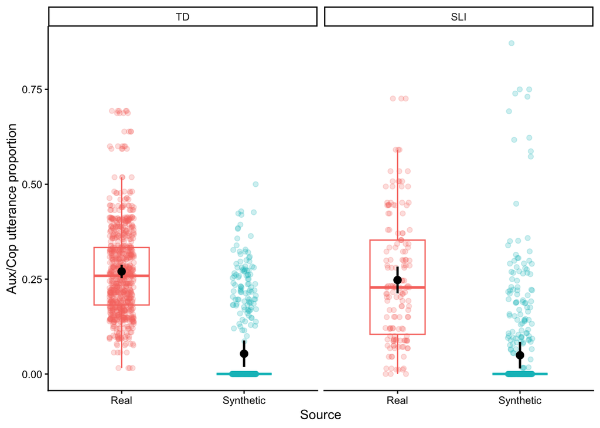

```r
library(dplyr)
library(ggplot2)
library(emmeans)

# Adjusted means from the primary model
emm_auxcop <- emmeans(
  m2_auxcop,
  ~ source_is_synthetic * clinical_group,
  at = list(source_is_synthetic = c(0, 1))
)

emm_auxcop_df <- as.data.frame(emm_auxcop) %>%
  mutate(
    source_label = factor(
      source_is_synthetic,
      levels = c(0, 1),
      labels = c("Real", "Synthetic")
    ),
    clinical_group = factor(clinical_group, levels = c("TD", "SLI"))
  )

# Raw data
df_plot <- df_all %>%
  mutate(
    source_label = factor(
      source_is_synthetic,
      levels = c(0, 1),
      labels = c("Real", "Synthetic")
    ),
    clinical_group = factor(clinical_group, levels = c("TD", "SLI"))
  ) %>%
  filter(!is.na(Syntax_AuxCop_Utt_Prop))

# Plot
ggplot(df_plot, aes(x = source_label, y = Syntax_AuxCop_Utt_Prop, color = source_label)) +
  geom_boxplot(width = 0.45, alpha = 0.15, outlier.shape = NA) +
  geom_jitter(width = 0.10, alpha = 0.22, size = 1.7) +
  geom_pointrange(
    data = emm_auxcop_df,
    aes(x = source_label, y = emmean, ymin = lower.CL, ymax = upper.CL),
    inherit.aes = FALSE,
    linewidth = 0.9,
    color = "black"
  ) +
  facet_wrap(~ clinical_group) +
  labs(
    x = "Source",
    y = "Aux/Cop utterance proportion"
  ) +
  theme_classic() +
  theme(legend.position = "none")
```

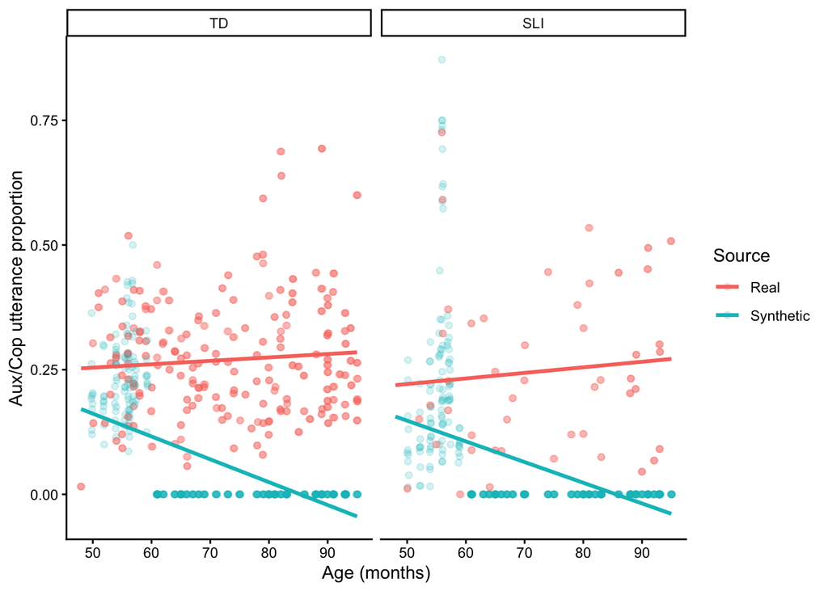

```r
age_mean <- mean(df_all$Age_Month, na.rm = TRUE)

df_age_plot <- df_all %>%
  mutate(
    Age_Month_plot = Age_c + age_mean,
    source_label = factor(
      source_is_synthetic,
      levels = c(0, 1),
      labels = c("Real", "Synthetic")
    ),
    clinical_group = factor(clinical_group, levels = c("TD", "SLI"))
  ) %>%
  filter(
    !is.na(Syntax_AuxCop_Utt_Prop),
    !is.na(Age_c),
    !is.na(Age_Month_plot)
  )

age_grid <- seq(
  min(df_age_plot$Age_c, na.rm = TRUE),
  max(df_age_plot$Age_c, na.rm = TRUE),
  length.out = 100
)

emm_age <- emmeans(
  m2_auxcop,
  ~ source_is_synthetic * clinical_group * Age_c,
  at = list(
    source_is_synthetic = c(0, 1),
    Age_c = age_grid
  )
)

pred_df <- as.data.frame(emm_age) %>%
  mutate(
    Age_Month_plot = Age_c + age_mean,
    source_label = factor(
      source_is_synthetic,
      levels = c(0, 1),
      labels = c("Real", "Synthetic")
    ),
    clinical_group = factor(clinical_group, levels = c("TD", "SLI"))
  )

ggplot(df_age_plot, aes(x = Age_Month_plot, y = Syntax_AuxCop_Utt_Prop, color = source_label)) +
  geom_jitter(width = 0.15, height = 0, alpha = 0.18, size = 1.6) +
  geom_line(
    data = pred_df,
    aes(x = Age_Month_plot, y = emmean, color = source_label),
    linewidth = 1.1,
    inherit.aes = FALSE
  ) +
  facet_wrap(~ clinical_group) +
  labs(
    x = "Age (months)",
    y = "Aux/Cop utterance proportion",
    color = "Source"
  ) +
  theme_classic()
```

#### determiners

```r
df_dev_all_clean <- df_dev_all_clean %>%
  mutate(
    det_art_per_utt = `det:art` / `#utterances`
  )
```

is age linear or quadratic?

```r
library(splines)
library(lme4)

m_lin_int <- lmer(
  det_art_per_utt ~ source_is_synthetic * clinical_group * Age_c +
    (1 | cluster_id),
  data = df_dev_all_clean, REML = FALSE
)

m_spline_int <- lmer(
  det_art_per_utt ~ source_is_synthetic * clinical_group +
    source_is_synthetic:ns(Age_Month, df = 3) +
    clinical_group:ns(Age_Month, df = 3) +
    ns(Age_Month, df = 3) +
    (1 | cluster_id),
  data = df_dev_all_clean, REML = FALSE
)

AIC(m_lin_int, m_spline_int)
```

```
##              df       AIC
## m_lin_int    10 -1343.779
## m_spline_int 15 -1353.604
```

```r
BIC(m_lin_int, m_spline_int)
```

```
##              df       BIC
## m_lin_int    10 -1292.032
## m_spline_int 15 -1275.983
```

```r
m0_detuse <- lmer(
  det_art_per_utt ~ source_is_synthetic * clinical_group +
     + (1 | cluster_id),
  data = df_dev_all_clean,
  REML = FALSE
)

m1_detuse <- lmer(
  det_art_per_utt ~ source_is_synthetic * clinical_group +
    Age_c  + (1 | cluster_id),
  data = df_dev_all_clean,
  REML = FALSE
)

m2_detuse <- lmer(
  det_art_per_utt ~ source_is_synthetic * clinical_group +
    Age_c +
    source_is_synthetic:Age_c +
    clinical_group:Age_c +
     + (1 | cluster_id),
  data = df_dev_all_clean,
  REML = FALSE
)

m3_detuse <- lmer(
  det_art_per_utt ~ source_is_synthetic * clinical_group * Age_c +
     + (1 | cluster_id),
  data = df_dev_all_clean,
  REML = FALSE
)

anova(m0_detuse, m1_detuse, m2_detuse, m3_detuse)
```

```
## Data: df_dev_all_clean
## Models:
## m0_detuse: det_art_per_utt ~ source_is_synthetic * clinical_group + +(1 | cluster_id)
## m1_detuse: det_art_per_utt ~ source_is_synthetic * clinical_group + Age_c + (1 | cluster_id)
## m2_detuse: det_art_per_utt ~ source_is_synthetic * clinical_group + Age_c + source_is_synthetic:Age_c + clinical_group:Age_c + +(1 | cluster_id)
## m3_detuse: det_art_per_utt ~ source_is_synthetic * clinical_group * Age_c + +(1 | cluster_id)
##           npar     AIC     BIC logLik -2*log(L)   Chisq Df Pr(>Chisq)
## m0_detuse    6 -1226.2 -1195.1 619.07   -1238.2
## m1_detuse    7 -1308.0 -1271.8 661.00   -1322.0 83.8517  1  < 2.2e-16 ***
## m2_detuse    9 -1345.8 -1299.2 681.88   -1363.8 41.7608  2  8.546e-10 ***
## m3_detuse   10 -1343.8 -1292.0 681.89   -1363.8  0.0195  1      0.889
## ---
## Signif. codes:  0 '***' 0.001 '**' 0.01 '*' 0.05 '.' 0.1 ' ' 1
```

```r
summary(m2_detuse)
```

```
## Linear mixed model fit by maximum likelihood . t-tests use Satterthwaite's
##   method [lmerModLmerTest]
## Formula: det_art_per_utt ~ source_is_synthetic * clinical_group + Age_c +
##     source_is_synthetic:Age_c + clinical_group:Age_c + +(1 |      cluster_id)
##    Data: df_dev_all_clean
##
##       AIC       BIC    logLik -2*log(L)  df.resid
##   -1345.8   -1299.2     681.9   -1363.8      1297
##
## Scaled residuals:
##     Min      1Q  Median      3Q     Max
## -3.6164 -0.1109 -0.0049  0.1067  4.7446
##
## Random effects:
##  Groups     Name        Variance Std.Dev.
##  cluster_id (Intercept) 0.067167 0.25917
##  Residual               0.009985 0.09993
## Number of obs: 1306, groups:  cluster_id, 281
##
## Fixed effects:
##                                         Estimate Std. Error         df t value
## (Intercept)                            8.587e-01  1.923e-02  2.800e+02  44.660
## source_is_synthetic                    1.874e-02  4.503e-02  3.059e+02   0.416
## clinical_groupSLI                     -2.690e-01  4.318e-02  2.836e+02  -6.230
## Age_c                                  1.203e-02  1.288e-03  2.902e+02   9.340
## source_is_synthetic:clinical_groupSLI  9.072e-02  4.540e-02  3.433e+02   1.998
## source_is_synthetic:Age_c             -1.060e-02  3.182e-03  2.862e+02  -3.332
## clinical_groupSLI:Age_c                5.061e-03  8.504e-04  1.177e+03   5.951
##                                       Pr(>|t|)
## (Intercept)                            < 2e-16 ***
## source_is_synthetic                   0.677592
## clinical_groupSLI                     1.68e-09 ***
## Age_c                                  < 2e-16 ***
## source_is_synthetic:clinical_groupSLI 0.046480 *
## source_is_synthetic:Age_c             0.000974 ***
## clinical_groupSLI:Age_c               3.50e-09 ***
## ---
## Signif. codes:  0 '***' 0.001 '**' 0.01 '*' 0.05 '.' 0.1 ' ' 1
##
## Correlation of Fixed Effects:
##             (Intr) src_s_ cl_SLI Age_c  s__:_S s__:A_
## src_s_synth -0.426
## clncl_grSLI -0.445  0.189
## Age_c        0.047  0.001 -0.012
## src_s_:_SLI  0.422 -0.250 -0.949 -0.017
## src_s_sy:A_ -0.018  0.119  0.003 -0.381 -0.034
## clnc_SLI:A_ -0.007 -0.154  0.008 -0.138  0.196 -0.118
```

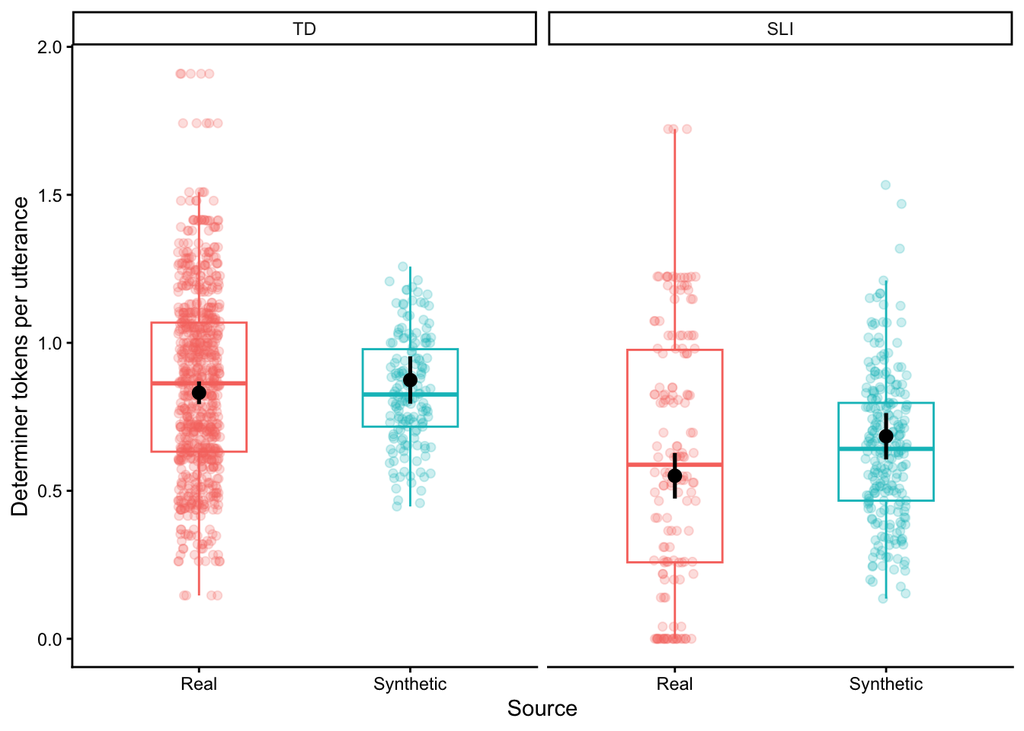

```r
library(dplyr)
library(ggplot2)
library(emmeans)

# Create emmeans object from the retained model
emm_detuse <- emmeans(
  m2_detuse,
  ~ source_is_synthetic * clinical_group,
  at = list(source_is_synthetic = c(0, 1))
)

emm_detuse_df <- as.data.frame(emm_detuse) %>%
  mutate(
    source_label = factor(
      source_is_synthetic,
      levels = c(0, 1),
      labels = c("Real", "Synthetic")
    ),
    clinical_group = factor(clinical_group, levels = c("TD", "SLI"))
  )

df_plot <- df_dev_all_clean %>%
  mutate(
    source_label = factor(
      source_is_synthetic,
      levels = c(0, 1),
      labels = c("Real", "Synthetic")
    ),
    clinical_group = factor(clinical_group, levels = c("TD", "SLI"))
  ) %>%
  filter(!is.na(det_art_per_utt))

ggplot(df_plot, aes(x = source_label, y = det_art_per_utt, color = source_label)) +
  geom_boxplot(width = 0.45, alpha = 0.15, outlier.shape = NA) +
  geom_jitter(width = 0.10, alpha = 0.22, size = 1.7) +
  geom_pointrange(
    data = emm_detuse_df,
    aes(x = source_label, y = emmean, ymin = lower.CL, ymax = upper.CL),
    inherit.aes = FALSE,
    linewidth = 0.9,
    color = "black"
  ) +
  facet_wrap(~ clinical_group) +
  labs(
    x = "Source",
    y = "Determiner tokens per utterance"
  ) +
  theme_classic() +
  theme(legend.position = "none")
```